# Курсовая работа №1

## 5. Метрика успеваемости

Иногда студенты берут курсы, которые оказываются для них неподъёмными. Это может быть как по причинам недостаточной изначальной подготовки, так и по причинам, связанным с низкой мотивацией студента. Для улучшения качества контента полезно выявить причину. На основании имеющихся данных придумаем и обоснуем метрику успеваемости студента.

Возможные метрики:

1. Время прохождения модуля студентом в сравнении с 90-процентилем времени прохождения модуля. - при условии, что все модули в статусе 'done', скорее скажет о том, что курс дается тяжело (обучение идет медленно), а не о низкой мотивации.
2. Процент начатых, но не завершенных успешно модулей (start/fail), от всех начатых модулей - может говорить также о том, что курс оказался слишком тяжелым для студента - есть попытки учиться, но они не заканчиваются успешно
3. Успешно пройдено 25% курса в адекватное время (до 75-процентиля), а последний модуль или в статусе start уже долгое время (дольше 75-процентиля) или вообще не начат - говорит о том, что курс был посильным, однако мотивация стала недостаточной.

Наиболее простой и четко описывающей необходимый результат представляется метрика номер 2, для 1 и 3 нужно более детально продумывать отсечки по времени прохождения и количеству пройденных модулей.

Рассчитаем процент начатых, но не завершенных успешно модулей для каждого студента. Однако отбросим последние для каждого студента и курса работы в статусе "start", если они были начаты позднее 1 мая 2019 года (датасет заканчивается июлем 2019 года) - они могут быть просто в процессе выполнения. (Возьмем только последние работы каждого студента, чтобы не отбрасывать возможных проблемных студентов последних месяцев)

```python
# добавим столбец для фильтрации
df_filter = df[df['status'] == 'start'].sort_values(by='start_date', ascending=True).groupby(['student_id', 'title'])[['start_date', 'progress_id', 'module_number']].last().reset_index(allow_duplicates=True)
df_filter['not_count'] = np.where(df_filter['start_date'].dt.tz_convert(None) > pd.to_datetime('2019-05-01'), 1, 0)

# добавим столбец not_count в общий датафрейм, чтобы обозначить записи,
#         которые мы не хотим учитывать при расчете - работы, начатые (в статусе start) позднее 1 мая 2019.

df = df.merge(df_filter[['student_id', 'title', 'start_date', 'not_count']], how='left', on=['student_id', 'title', 'start_date']).fillna(0)
df
```

|  | progress_id | module_number | lesson_number | status | start_date | finish_date | student_id | course_id | title | field | module_title | lesson_title | lesson_token | is_video | is_homework | first_hw_mod | first_hw_les | start_year_month | finish_year_month | not_count |
| --- | --- | --- | --- | --- | --- | --- | --- | --- | --- | --- | --- | --- | --- | --- | --- | --- | --- | --- | --- | --- |
| 0 | a387ab916f402cb3fbfffd29f68fd0ce | 2 | 4 | done | 2018-06-23 08:28:50.681065+00:00 | 2018-06-23 08:28:52.439542+00:00 | 768c2987a744c51ce64a5993a2a94eaf | c9fcb746d51e41bc5a217002d081454b | Веб-дизайн PRO 2.0 | Design | Концептуальный дизайн | Практика — мокапы | 7df8adef-1259-4b72-9bf2-353c73389d06 | True | False | 1 | 6 | 2018-06-01 | 2018-06-01 00:00:00 | 0.0 |
| 1 | a387ab916f402cb3fbfffd29f68fd0ce | 1 | 1 | done | 2018-06-20 14:25:21.783762+00:00 | 2018-06-20 15:45:07.717209+00:00 | 768c2987a744c51ce64a5993a2a94eaf | c9fcb746d51e41bc5a217002d081454b | Веб-дизайн PRO 2.0 | Design | Специализация и личное позиционирование | Интро курса | df1a1f20-cdf7-443d-b25b-0a4b990b84d9 | True | False | 1 | 6 | 2018-06-01 | 2018-06-01 00:00:00 | 0.0 |
| 2 | a387ab916f402cb3fbfffd29f68fd0ce | 2 | 2 | done | 2018-06-23 08:18:09.653771+00:00 | 2018-06-23 08:18:12.784616+00:00 | 768c2987a744c51ce64a5993a2a94eaf | c9fcb746d51e41bc5a217002d081454b | Веб-дизайн PRO 2.0 | Design | Концептуальный дизайн | Что такое концептуальный дизайн | f23b1890-9365-406f-816b-04864cefe58f | True | False | 1 | 6 | 2018-06-01 | 2018-06-01 00:00:00 | 0.0 |
| 3 | a387ab916f402cb3fbfffd29f68fd0ce | 1 | 4 | done | 2018-06-20 16:00:06.361780+00:00 | 2018-06-21 19:09:30.845034+00:00 | 768c2987a744c51ce64a5993a2a94eaf | c9fcb746d51e41bc5a217002d081454b | Веб-дизайн PRO 2.0 | Design | Специализация и личное позиционирование | Личное позиционирование | 9dd50916-4aa6-4a73-b86c-56a1bd7753c8 | True | False | 1 | 6 | 2018-06-01 | 2018-06-01 00:00:00 | 0.0 |
| 4 | a387ab916f402cb3fbfffd29f68fd0ce | 1 | 6 | done | 2018-06-21 19:10:36.957891+00:00 | 2018-06-28 15:59:25.320418+00:00 | 768c2987a744c51ce64a5993a2a94eaf | c9fcb746d51e41bc5a217002d081454b | Веб-дизайн PRO 2.0 | Design | Специализация и личное позиционирование | Домашняя работа | 43e1fbdd-1ee9-4ed5-a577-4dadd80c02b3 | False | True | 1 | 6 | 2018-06-01 | 2018-06-01 00:00:00 | 0.0 |
| ... | ... | ... | ... | ... | ... | ... | ... | ... | ... | ... | ... | ... | ... | ... | ... | ... | ... | ... | ... | ... |
| 350672 | ea9c93865c1de54a5079b7ae71c88683 | 3 | 2 | start | 2019-07-16 23:02:33.482900+00:00 | 0 | 25ec58029696f8b7de38d22e5e01c7ea | bf27a4bf4ada4c756451703ea62a914f | Интернет-маркетолог от Ingate | Marketing | SEO: больше, чем поисковая выдача (обновление ... | Что такое SEO | 54905985-9222-493c-bebe-cbdf4c6535b1 | True | False | 1 | 7 | 2019-07-01 | 0 | 1.0 |
| 350673 | ea9c93865c1de54a5079b7ae71c88683 | 2 | 4 | done | 2019-07-02 15:34:32.134806+00:00 | 2019-07-02 16:32:15.491277+00:00 | 25ec58029696f8b7de38d22e5e01c7ea | bf27a4bf4ada4c756451703ea62a914f | Интернет-маркетолог от Ingate | Marketing | Исследование целевой аудитории: портретировани... | Построение карты путей пользователя | dc58b42e-8440-4e08-9706-099b228fd534 | True | False | 1 | 7 | 2019-07-01 | 2019-07-01 00:00:00 | 0.0 |
| 350674 | ea9c93865c1de54a5079b7ae71c88683 | 2 | 3 | done | 2019-07-01 21:46:27.908354+00:00 | 2019-07-01 21:48:04.806799+00:00 | 25ec58029696f8b7de38d22e5e01c7ea | bf27a4bf4ada4c756451703ea62a914f | Интернет-маркетолог от Ingate | Marketing | Исследование целевой аудитории: портретировани... | Сбор данных | b19caa4b-bf5d-4db4-86fb-a65ffe63fc00 | True | False | 1 | 7 | 2019-07-01 | 2019-07-01 00:00:00 | 0.0 |
| 350675 | ea9c93865c1de54a5079b7ae71c88683 | 2 | 2 | done | 2019-06-30 22:41:33.705765+00:00 | 2019-07-01 07:44:00.370798+00:00 | 25ec58029696f8b7de38d22e5e01c7ea | bf27a4bf4ada4c756451703ea62a914f | Интернет-маркетолог от Ingate | Marketing | Исследование целевой аудитории: портретировани... | Сегментация ЦА и составление портрета клиента | d1ddacdc-797c-4115-afd4-31a05cda738d | True | False | 1 | 7 | 2019-06-01 | 2019-07-01 00:00:00 | 0.0 |
| 350676 | ea9c93865c1de54a5079b7ae71c88683 | 3 | 1 | done | 2019-07-14 23:36:52.318819+00:00 | 2019-07-15 12:21:47.908115+00:00 | 25ec58029696f8b7de38d22e5e01c7ea | bf27a4bf4ada4c756451703ea62a914f | Интернет-маркетолог от Ingate | Marketing | SEO: больше, чем поисковая выдача (обновление ... | Поисковые системы | 24a3760d-6e3f-4bf0-92d3-2cc3f3b0c781 | True | False | 1 | 7 | 2019-07-01 | 2019-07-01 00:00:00 | 0.0 |

350677 rows × 20 columns

```python
# рассчитаем все не законченные работы по студентам и курсам (статусы start и fail)
df_bad = df[(df['status'].isin(['start', 'fail'])) & (df['not_count'] == 0)].groupby(['student_id', 'title'])['status'].count().reset_index()
df_bad.columns = ['student', 'course', 'not_finished_lessons']
display(df_bad)

# рассчитаем кол-во всех работ для каждого студента по курсам
df_all = df[(df['not_count'] == 0)].groupby(['student_id', 'title'])['status'].count().reset_index()
df_all.columns = ['student', 'course', 'started_lessons']
display(df_all)
```

|  | student | course | not_finished_lessons |
| --- | --- | --- | --- |
| 0 | 000333b6aa5706c53f4d2ec24c7a128d | SMM-маркетолог от А до Я | 3 |
| 1 | 0007e271c3f2f20ff8675df9d81e0401 | Веб-дизайн PRO 2.0 | 1 |
| 2 | 0010ab47e706e3ae6ac718d5cf06b752 | Интернет-маркетолог от Ingate | 1 |
| 3 | 001b192f899a84496be98b41906246fc | Excel Базовый | 1 |
| 4 | 00386b771938472b2df62108f5985c1e | UX-дизайн | 1 |
| ... | ... | ... | ... |
| 10250 | ffc165fc00d0172ec1bea5397e67ade8 | Интернет-маркетолог от Ingate | 1 |
| 10251 | ffcab072956be8f20917dddb726be5ad | Интернет-маркетолог от Ingate | 1 |
| 10252 | ffd7a91bcf8acfe1afd2e74c7374cf23 | Веб-вёрстка для начинающих 2.0 | 2 |
| 10253 | ffef4e9e2855886ae9aaac19cd5020e6 | Интернет-маркетолог от Ingate | 1 |
| 10254 | fff9c6b403f88a6b83dc1837a93dc4dd | Java-разработчик | 1 |

10255 rows × 3 columns

|  | student | course | started_lessons |
| --- | --- | --- | --- |
| 0 | 000333b6aa5706c53f4d2ec24c7a128d | SMM-маркетолог от А до Я | 36 |
| 1 | 0007e271c3f2f20ff8675df9d81e0401 | Веб-дизайн PRO 2.0 | 1 |
| 2 | 0007e271c3f2f20ff8675df9d81e0401 | Веб-дизайн с нуля 2.0 | 44 |
| 3 | 000ca3ad0aaedff60d95d309b038210b | Интернет-маркетолог от Ingate | 54 |
| 4 | 0010ab47e706e3ae6ac718d5cf06b752 | Интернет-маркетолог от Ingate | 56 |
| ... | ... | ... | ... |
| 15730 | ffd7a91bcf8acfe1afd2e74c7374cf23 | Веб-вёрстка для начинающих 2.0 | 27 |
| 15731 | ffe5329154259d3f3f5eee58a06ef6f5 | Java-разработчик c нуля | 7 |
| 15732 | ffef4e9e2855886ae9aaac19cd5020e6 | Интернет-маркетолог от Ingate | 7 |
| 15733 | fff9c6b403f88a6b83dc1837a93dc4dd | Java-разработчик | 87 |
| 15734 | fffc0307abdaa5ba8bf0b6e88b101712 | Интернет-маркетолог от Ingate | 1 |

15735 rows × 3 columns

```python
# объединим датасеты, заполняя NaN в колонке с не законченными модулями нулями
df_all = df_all.merge(df_bad, how='left', on=('course', 'student')).fillna(0)
```

```python
# рассчитаем количество уроков в каждом курсе
df_lesson_count = df.groupby(['title', 'module_number'])['lesson_number'].nunique().reset_index().groupby('title')['lesson_number'].sum().reset_index()
df_lesson_count.columns = ['course', 'total_lessons']

# добавим столбец с общим кол-вом уроков по курсу в датафрейм с подсчетом законченных и не законченных работ студентами
df_all = df_all.merge(df_lesson_count, how='left', on='course')
df_all
```

|  | student | course | started_lessons | not_finished_lessons | total_lessons |
| --- | --- | --- | --- | --- | --- |
| 0 | 000333b6aa5706c53f4d2ec24c7a128d | SMM-маркетолог от А до Я | 36 | 3.0 | 62 |
| 1 | 0007e271c3f2f20ff8675df9d81e0401 | Веб-дизайн PRO 2.0 | 1 | 1.0 | 66 |
| 2 | 0007e271c3f2f20ff8675df9d81e0401 | Веб-дизайн с нуля 2.0 | 44 | 0.0 | 82 |
| 3 | 000ca3ad0aaedff60d95d309b038210b | Интернет-маркетолог от Ingate | 54 | 0.0 | 171 |
| 4 | 0010ab47e706e3ae6ac718d5cf06b752 | Интернет-маркетолог от Ingate | 56 | 1.0 | 171 |
| ... | ... | ... | ... | ... | ... |
| 15730 | ffd7a91bcf8acfe1afd2e74c7374cf23 | Веб-вёрстка для начинающих 2.0 | 27 | 2.0 | 55 |
| 15731 | ffe5329154259d3f3f5eee58a06ef6f5 | Java-разработчик c нуля | 7 | 0.0 | 115 |
| 15732 | ffef4e9e2855886ae9aaac19cd5020e6 | Интернет-маркетолог от Ingate | 7 | 1.0 | 171 |
| 15733 | fff9c6b403f88a6b83dc1837a93dc4dd | Java-разработчик | 87 | 1.0 | 114 |
| 15734 | fffc0307abdaa5ba8bf0b6e88b101712 | Интернет-маркетолог от Ingate | 1 | 0.0 | 171 |

15735 rows × 5 columns

```python
df_all.info()
```

```
<class 'pandas.core.frame.DataFrame'>
Int64Index: 15735 entries, 0 to 15734
Data columns (total 5 columns):
 #   Column                Non-Null Count  Dtype
---  ------                --------------  -----
 0   student               15735 non-null  object
 1   course                15735 non-null  object
 2   started_lessons       15735 non-null  int64
 3   not_finished_lessons  15735 non-null  float64
 4   total_lessons         15735 non-null  int64
dtypes: float64(1), int64(2), object(2)
memory usage: 737.6+ KB
```

```python
# рассчитаем процент начатых, но не законченных уроков от всех начатых уроков- чем ниже процент, тем вероятнее, что курс дается студенту хорошо
df_all['percent_not_finished_from_all_started'] = (df_all['not_finished_lessons'] / df_all['started_lessons'] * 100).round(2)

# рассчитаем процент уроков, которые студент вообще начинал (не имеет значения статус), от всех уроков курса - чем выше процент, тем вероятнее, что курс дается студенту хорошо
df_all['percent_started_from_total_lessons'] = (df_all['started_lessons'] / df_all['total_lessons'] * 100).round(2)
df_all
```

|  | student | course | started_lessons | not_finished_lessons | total_lessons | percent_not_finished_from_all_started | percent_started_from_total_lessons |
| --- | --- | --- | --- | --- | --- | --- | --- |
| 0 | 000333b6aa5706c53f4d2ec24c7a128d | SMM-маркетолог от А до Я | 36 | 3.0 | 62 | 8.33 | 58.06 |
| 1 | 0007e271c3f2f20ff8675df9d81e0401 | Веб-дизайн PRO 2.0 | 1 | 1.0 | 66 | 100.00 | 1.52 |
| 2 | 0007e271c3f2f20ff8675df9d81e0401 | Веб-дизайн с нуля 2.0 | 44 | 0.0 | 82 | 0.00 | 53.66 |
| 3 | 000ca3ad0aaedff60d95d309b038210b | Интернет-маркетолог от Ingate | 54 | 0.0 | 171 | 0.00 | 31.58 |
| 4 | 0010ab47e706e3ae6ac718d5cf06b752 | Интернет-маркетолог от Ingate | 56 | 1.0 | 171 | 1.79 | 32.75 |
| ... | ... | ... | ... | ... | ... | ... | ... |
| 15730 | ffd7a91bcf8acfe1afd2e74c7374cf23 | Веб-вёрстка для начинающих 2.0 | 27 | 2.0 | 55 | 7.41 | 49.09 |
| 15731 | ffe5329154259d3f3f5eee58a06ef6f5 | Java-разработчик c нуля | 7 | 0.0 | 115 | 0.00 | 6.09 |
| 15732 | ffef4e9e2855886ae9aaac19cd5020e6 | Интернет-маркетолог от Ingate | 7 | 1.0 | 171 | 14.29 | 4.09 |
| 15733 | fff9c6b403f88a6b83dc1837a93dc4dd | Java-разработчик | 87 | 1.0 | 114 | 1.15 | 76.32 |
| 15734 | fffc0307abdaa5ba8bf0b6e88b101712 | Интернет-маркетолог от Ingate | 1 | 0.0 | 171 | 0.00 | 0.58 |

15735 rows × 7 columns

Основной расчет был сделал, теперь важно верно выбрать отсечки, чтобы отразить именно тех студентов, которых мы считаем проблемными. Предлагается выбрать студентов, которые не завершили 50% работ, но при этом начали более 2. Таким образом отсеем тех людей, которые начали пока слишком мало работ, чтобы судить о том, что им не удается их закончить.

```python
# отберем тех у кого процент не законченных от всех начатых работ выше 50% и количество начатых уроков больше 2
troubles = df_all[(df_all['percent_not_finished_from_all_started'] >= 50) & (df_all['started_lessons'] > 2)]

# отсортируем по частоте встречаемости в датасете проблемных студентов
sorted_courses = troubles['course'].value_counts().index.tolist()
troubles = troubles.sort_values(by='course', key=lambda x: x.map({val: i for i, val in enumerate(sorted_courses)}))

# добавим сферы курсов
troubles = troubles.merge(df[['title', 'field']].drop_duplicates(), how='left', left_on='course', right_on='title')
```

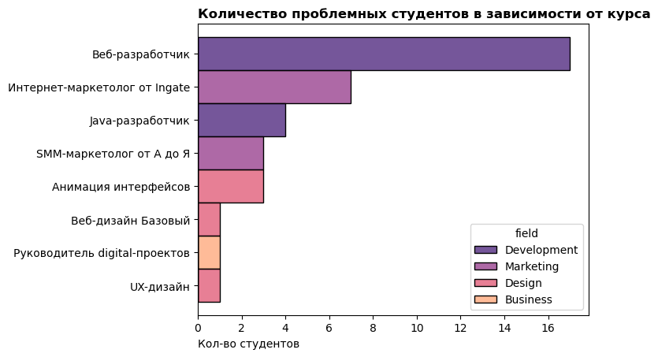

```python
sns.histplot(troubles, y='course', hue='field', palette='magma', alpha=0.7)
plt.title('Количество проблемных студентов в зависимости от курса', loc='left', weight='bold')
plt.xlabel('Кол-во студентов', loc='left')
plt.ylabel('')

plt.show()
```

### Вывод:

Заметно большое количество студентов с проблемами на курсе веб-разработчик, возможно, стоит пересмотреть материал и задания курса. Без учета курса Веб-разработчик наибольшее количество проблемный студентов присутствует на курсах направления Маркетинг.